# Курсовая работа

## Факторы влияющие на качество вина

```python
import numpy as np
import pandas as pd
import matplotlib as mpl
import matplotlib.pyplot as plt
import seaborn as sns
import warnings; warnings.filterwarnings(action='once')
import statsmodels.api as sm
import pylab
from mpl_toolkits.mplot3d import Axes3D
from scipy.cluster.hierarchy import dendrogram, linkage, fcluster

large = 22; med = 16; small = 12
params = {'axes.titlesize': large,
          'legend.fontsize': med,
          'figure.figsize': (16, 10),
          'axes.labelsize': med,
          'axes.titlesize': med,
          'xtick.labelsize': med,
          'ytick.labelsize': med,
          'figure.titlesize': large}
plt.rcParams.update(params)
plt.style.use('seaborn-whitegrid')
sns.set_style("white")
%matplotlib inline
```

```python
df = pd.read_csv('winequality-red.csv', sep=";")
```

```python
df
```

|  | fixed acidity | volatile acidity | citric acid | residual sugar | chlorides | free sulfur dioxide | total sulfur dioxide | density | pH | sulphates | alcohol | quality |
| --- | --- | --- | --- | --- | --- | --- | --- | --- | --- | --- | --- | --- |
| 0 | 7.4 | 0.700 | 0.00 | 1.9 | 0.076 | 11.0 | 34.0 | 0.99780 | 3.51 | 0.56 | 9.4 | 5 |
| 1 | 7.8 | 0.880 | 0.00 | 2.6 | 0.098 | 25.0 | 67.0 | 0.99680 | 3.20 | 0.68 | 9.8 | 5 |
| 2 | 7.8 | 0.760 | 0.04 | 2.3 | 0.092 | 15.0 | 54.0 | 0.99700 | 3.26 | 0.65 | 9.8 | 5 |
| 3 | 11.2 | 0.280 | 0.56 | 1.9 | 0.075 | 17.0 | 60.0 | 0.99800 | 3.16 | 0.58 | 9.8 | 6 |
| 4 | 7.4 | 0.700 | 0.00 | 1.9 | 0.076 | 11.0 | 34.0 | 0.99780 | 3.51 | 0.56 | 9.4 | 5 |
| ... | ... | ... | ... | ... | ... | ... | ... | ... | ... | ... | ... | ... |
| 1594 | 6.2 | 0.600 | 0.08 | 2.0 | 0.090 | 32.0 | 44.0 | 0.99490 | 3.45 | 0.58 | 10.5 | 5 |
| 1595 | 5.9 | 0.550 | 0.10 | 2.2 | 0.062 | 39.0 | 51.0 | 0.99512 | 3.52 | 0.76 | 11.2 | 6 |
| 1596 | 6.3 | 0.510 | 0.13 | 2.3 | 0.076 | 29.0 | 40.0 | 0.99574 | 3.42 | 0.75 | 11.0 | 6 |
| 1597 | 5.9 | 0.645 | 0.12 | 2.0 | 0.075 | 32.0 | 44.0 | 0.99547 | 3.57 | 0.71 | 10.2 | 5 |
| 1598 | 6.0 | 0.310 | 0.47 | 3.6 | 0.067 | 18.0 | 42.0 | 0.99549 | 3.39 | 0.66 | 11.0 | 6 |

1599 rows × 12 columns

### Построим граффик корреляции признаков

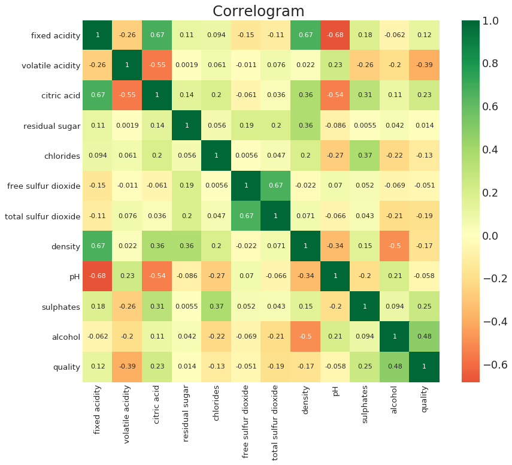

```python
plt.figure(figsize=(12,10), dpi= 80)
sns.heatmap(df.corr(), xticklabels=df.corr().columns, yticklabels=df.corr().columns, cmap='RdYlGn', center=0, annot=True)

# Decorations
plt.title('Correlogram ', fontsize=22)
plt.xticks(fontsize=12)
plt.yticks(fontsize=12)
plt.show()
```

Попробуем разбить наш датасет на кластеры, построим диаграмму

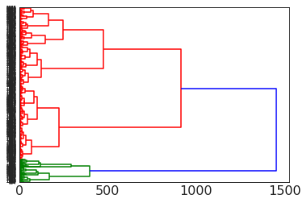

```python
df_num = df.select_dtypes(include=['float64', 'int64']).drop('quality', axis=1)

link = linkage(df_num, 'ward', 'euclidean')
dn = dendrogram(link, orientation='right')
```

Видим, что получается 2 класса, но они будут сильно несбалансированны

## Понизим размерность методом главных компонент

С начала **Центрируем** матрицу df, вычив из каждого признака его среднее

```python
df.describe()
```

|  | fixed acidity | volatile acidity | citric acid | residual sugar | chlorides | free sulfur dioxide | total sulfur dioxide | density | pH | sulphates | alcohol | quality |
| --- | --- | --- | --- | --- | --- | --- | --- | --- | --- | --- | --- | --- |
| count | 1599.000000 | 1599.000000 | 1599.000000 | 1599.000000 | 1599.000000 | 1599.000000 | 1599.000000 | 1599.000000 | 1599.000000 | 1599.000000 | 1599.000000 | 1599.000000 |
| mean | 8.319637 | 0.527821 | 0.270976 | 2.538806 | 0.087467 | 15.874922 | 46.467792 | 0.996747 | 3.311113 | 0.658149 | 10.422983 | 5.636023 |
| std | 1.741096 | 0.179060 | 0.194801 | 1.409928 | 0.047065 | 10.460157 | 32.895324 | 0.001887 | 0.154386 | 0.169507 | 1.065668 | 0.807569 |
| min | 4.600000 | 0.120000 | 0.000000 | 0.900000 | 0.012000 | 1.000000 | 6.000000 | 0.990070 | 2.740000 | 0.330000 | 8.400000 | 3.000000 |
| 25% | 7.100000 | 0.390000 | 0.090000 | 1.900000 | 0.070000 | 7.000000 | 22.000000 | 0.995600 | 3.210000 | 0.550000 | 9.500000 | 5.000000 |
| 50% | 7.900000 | 0.520000 | 0.260000 | 2.200000 | 0.079000 | 14.000000 | 38.000000 | 0.996750 | 3.310000 | 0.620000 | 10.200000 | 6.000000 |
| 75% | 9.200000 | 0.640000 | 0.420000 | 2.600000 | 0.090000 | 21.000000 | 62.000000 | 0.997835 | 3.400000 | 0.730000 | 11.100000 | 6.000000 |
| max | 15.900000 | 1.580000 | 1.000000 | 15.500000 | 0.611000 | 72.000000 | 289.000000 | 1.003690 | 4.010000 | 2.000000 | 14.900000 | 8.000000 |

Перемещаем целевую переменную в отдельный датасет, так как она нам не пригодится для метода главных компонент

```python
df_dq = df.drop(['quality'], axis='columns')
```

Проверяем, получился тот же датасет без целевой переменной, можно приступать к уменьшению размерности

```python
df_dq
```

|  | fixed acidity | volatile acidity | citric acid | residual sugar | chlorides | free sulfur dioxide | total sulfur dioxide | density | pH | sulphates | alcohol |
| --- | --- | --- | --- | --- | --- | --- | --- | --- | --- | --- | --- |
| 0 | 7.4 | 0.700 | 0.00 | 1.9 | 0.076 | 11.0 | 34.0 | 0.99780 | 3.51 | 0.56 | 9.4 |
| 1 | 7.8 | 0.880 | 0.00 | 2.6 | 0.098 | 25.0 | 67.0 | 0.99680 | 3.20 | 0.68 | 9.8 |
| 2 | 7.8 | 0.760 | 0.04 | 2.3 | 0.092 | 15.0 | 54.0 | 0.99700 | 3.26 | 0.65 | 9.8 |
| 3 | 11.2 | 0.280 | 0.56 | 1.9 | 0.075 | 17.0 | 60.0 | 0.99800 | 3.16 | 0.58 | 9.8 |
| 4 | 7.4 | 0.700 | 0.00 | 1.9 | 0.076 | 11.0 | 34.0 | 0.99780 | 3.51 | 0.56 | 9.4 |
| ... | ... | ... | ... | ... | ... | ... | ... | ... | ... | ... | ... |
| 1594 | 6.2 | 0.600 | 0.08 | 2.0 | 0.090 | 32.0 | 44.0 | 0.99490 | 3.45 | 0.58 | 10.5 |
| 1595 | 5.9 | 0.550 | 0.10 | 2.2 | 0.062 | 39.0 | 51.0 | 0.99512 | 3.52 | 0.76 | 11.2 |
| 1596 | 6.3 | 0.510 | 0.13 | 2.3 | 0.076 | 29.0 | 40.0 | 0.99574 | 3.42 | 0.75 | 11.0 |
| 1597 | 5.9 | 0.645 | 0.12 | 2.0 | 0.075 | 32.0 | 44.0 | 0.99547 | 3.57 | 0.71 | 10.2 |
| 1598 | 6.0 | 0.310 | 0.47 | 3.6 | 0.067 | 18.0 | 42.0 | 0.99549 | 3.39 | 0.66 | 11.0 |

1599 rows × 11 columns

Первым делом центруем данные, вычитая из значений их среднее

```python
df_dq = df_dq - df_dq.mean(axis=0)
```

Посмотрим среднее по новым данным

```python
df_dq.mean(axis=0)
```

```
fixed acidity          -2.743799e-14
volatile acidity       -3.210204e-16
citric acid             1.144609e-15
residual sugar         -1.878700e-15
chlorides               2.522997e-16
free sulfur dioxide     9.291713e-15
total sulfur dioxide   -7.212964e-14
density                 7.107788e-16
pH                     -9.006762e-16
sulphates              -3.277206e-16
alcohol                 2.580661e-14
dtype: float64
```

Теперь данные центрированы, можно приступить к создание ковариционной матрицы

Построим ковариционную матрицу,

TODO: Нужно ли в pandas транспонировать данные, перед тем как считать ковариционную матрицу??

```python
cov = df_dq.cov(min_periods=None)
cov
```

|  | fixed acidity | volatile acidity | citric acid | residual sugar | chlorides | free sulfur dioxide | total sulfur dioxide | density | pH | sulphates | alcohol |
| --- | --- | --- | --- | --- | --- | --- | --- | --- | --- | --- | --- |
| fixed acidity | 3.031416 | -0.079851 | 0.227820 | 0.281756 | 0.007679 | -2.800921 | -6.482346 | 0.002195 | -0.183586 | 0.054010 | -0.114421 |
| volatile acidity | -0.079851 | 0.032062 | -0.019272 | 0.000484 | 0.000517 | -0.019674 | 0.450426 | 0.000007 | 0.006495 | -0.007921 | -0.038600 |
| citric acid | 0.227820 | -0.019272 | 0.037947 | 0.039434 | 0.001869 | -0.124252 | 0.227697 | 0.000134 | -0.016298 | 0.010328 | 0.022815 |
| residual sugar | 0.281756 | 0.000484 | 0.039434 | 1.987897 | 0.003690 | 2.758611 | 9.416441 | 0.000945 | -0.018644 | 0.001321 | 0.063219 |
| chlorides | 0.007679 | 0.000517 | 0.001869 | 0.003690 | 0.002215 | 0.002738 | 0.073387 | 0.000018 | -0.001926 | 0.002962 | -0.011092 |
| free sulfur dioxide | -2.800921 | -0.019674 | -0.124252 | 2.758611 | 0.002738 | 109.414884 | 229.737521 | -0.000433 | 0.113653 | 0.091592 | -0.773698 |
| total sulfur dioxide | -6.482346 | 0.450426 | 0.227697 | 9.416441 | 0.073387 | 229.737521 | 1082.102373 | 0.004425 | -0.337699 | 0.239471 | -7.209298 |
| density | 0.002195 | 0.000007 | 0.000134 | 0.000945 | 0.000018 | -0.000433 | 0.004425 | 0.000004 | -0.000100 | 0.000048 | -0.000998 |
| pH | -0.183586 | 0.006495 | -0.016298 | -0.018644 | -0.001926 | 0.113653 | -0.337699 | -0.000100 | 0.023835 | -0.005146 | 0.033832 |
| sulphates | 0.054010 | -0.007921 | 0.010328 | 0.001321 | 0.002962 | 0.091592 | 0.239471 | 0.000048 | -0.005146 | 0.028733 | 0.016907 |
| alcohol | -0.114421 | -0.038600 | 0.022815 | 0.063219 | -0.011092 | -0.773698 | -7.209298 | -0.000998 | 0.033832 | 0.016907 | 1.135647 |

```python
cov.var(axis=0, ddof=1)
```

```
fixed acidity                5.590852
volatile acidity             0.020306
citric acid                  0.010830
residual sugar               8.110991
chlorides                    0.000500
free sulfur dioxide       5435.662033
total sulfur dioxide    106832.198319
density                      0.000002
pH                           0.014954
sulphates                    0.005298
alcohol                      4.958520
dtype: float64
```

Посчитаем собственные вектора и собственные значения

```python
eigenvalues, eigenvectors = np.linalg.eig(cov)
eigenvalues
```

```
array([1.13380708e+03, 5.79354108e+01, 3.10130228e+00, 1.81941532e+00,
       1.04634036e+00, 4.13967294e-02, 2.31926578e-02, 1.13464685e-02,
       1.00779841e-02, 1.45499755e-03, 5.61482667e-07])
```

Выбираем самые большие собственные значения из получившихся, чтобы по ним выбрать собственные вектора для дальнейших преобразований

```python
print(eigenvalues[0],eigenvalues[1] )
```

```
1133.8070755113827 57.93541077477589
```

Собственный вектор, с наибольшим вкладом, на который будем умножать датафрейм

```python
print(eigenvectors[:, [1, 0]])
```

```
[[-2.38994985e-02  6.13247431e-03]
 [-2.00966661e-03 -3.84465551e-04]
 [-3.03480788e-03 -1.70902595e-04]
 [ 1.11348551e-02 -8.64894648e-03]
 [-2.36654751e-04 -6.37307290e-05]
 [ 9.75265982e-01 -2.18857434e-01]
 [-2.18916841e-01 -9.75678369e-01]
 [-2.49998510e-05 -3.72498542e-06]
 [ 3.27182194e-03  2.68008619e-04]
 [ 6.18926046e-04 -2.23381730e-04]
 [ 1.45642451e-02  6.35846721e-03]]
```

Умножаем исходную матрицу без столбца целывых переменных на два собственных вектора, чтобы получить датафрейм из двух фич

```python
new_df = df_dq.dot(eigenvectors[:, [1, 0]])
```

Смотрим, что у нас получилось, дополнив матрицу столбцом качества

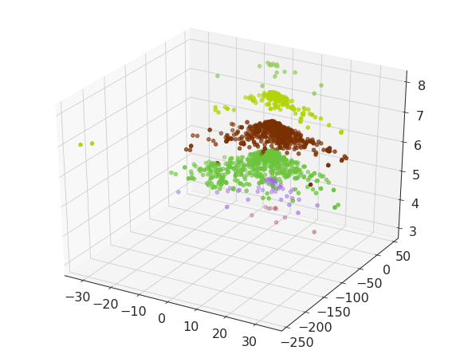

```python
colors= ["#049FBB", "#5DF10A", "#BF5B3F", "#A95058", "#9C6BE1","#6CC43C","#7B3001", "#B3D407","#97CE66"] #hex colours

fig = plt.figure(figsize=(10, 8))
ax = fig.add_subplot(111, projection='3d')

x = new_df[0]
y = new_df[1]
z = df['quality']

ax.scatter(x, y, z, c=[colors[i] for i in z],  depthshade=True)

plt.show()
```

TODO: посмотреть что за вино, которое кажется выбрасом

На графике не очень видна глубина

Смотрим, как хорошо у нас все получилось.

Формула **объяснённой дисперсии** То есть, дисперсии до и после

$$\frac{\sigma^2_Y}{\sigma^2_X}$$

$\sigma_{X}^2$ - дисперсия до применения метода, без учета quality

```python
variance_before = df_dq.var(ddof=1).sum()
variance_before
```

```
1197.7970136447661
```

$\sigma_{Y}^2$ - дисперсия после

```python
variance_after = new_df.var(ddof=1).sum()
variance_after
```

```
1191.7424862861535
```

```python
variance_after / variance_before
```

```
0.9949452809702795
```

Такое значение доли объяснённой дисперсии можно интерпретировать так: используя новые данные вместо старых, мы сохраним около $99.4\%$ информации, т.е. потеряем лишь $0.6\%$, что довольно неплохо.

## Проверим распределение фич на нормальность

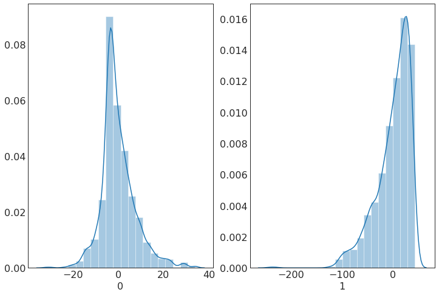

```python
fig, ax =plt.subplots(1,2,figsize=(12,8))

sns.distplot(x1, bins=20, ax=ax[0])
sns.distplot(x2, bins=20, ax=ax[1])
plt.show()
```

Первая фича имеет, что то похожее на нормальное распределение. Вторая точно нет.

#### Построим Q-Q plot

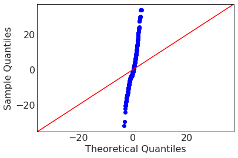

```python
sm.qqplot(x1, line='45')
pylab.show()
```

Точно видим, что никакого нормального разделения тут нет

## Линейная регрессия

Мы видели из граффики кореляции, какие фичи наиболее сильно влияют на качества вина

$$y_i = b_0 + b_1x_{1i} + b_2x_{12} +\dots+b_{m}x_{mi} + \epsilon_{i}$$

Коэффиценты линейной регрессии $$b_0, b_1, b_2, \dots, b_m $$

Где $\epsilon$ - ошибка $$\epsilon_{i} = \hat{y_{i}} - y_i$$

Подготовим данные

```python
df.head()
```

|  | fixed acidity | volatile acidity | citric acid | residual sugar | chlorides | free sulfur dioxide | total sulfur dioxide | density | pH | sulphates | alcohol | quality |
| --- | --- | --- | --- | --- | --- | --- | --- | --- | --- | --- | --- | --- |
| 0 | 7.4 | 0.70 | 0.00 | 1.9 | 0.076 | 11.0 | 34.0 | 0.9978 | 3.51 | 0.56 | 9.4 | 5 |
| 1 | 7.8 | 0.88 | 0.00 | 2.6 | 0.098 | 25.0 | 67.0 | 0.9968 | 3.20 | 0.68 | 9.8 | 5 |
| 2 | 7.8 | 0.76 | 0.04 | 2.3 | 0.092 | 15.0 | 54.0 | 0.9970 | 3.26 | 0.65 | 9.8 | 5 |
| 3 | 11.2 | 0.28 | 0.56 | 1.9 | 0.075 | 17.0 | 60.0 | 0.9980 | 3.16 | 0.58 | 9.8 | 6 |
| 4 | 7.4 | 0.70 | 0.00 | 1.9 | 0.076 | 11.0 | 34.0 | 0.9978 | 3.51 | 0.56 | 9.4 | 5 |

```python
x1 = df[['volatile acidity','alcohol','sulphates', 'citric acid']].values

y = df['quality'].values.reshape(-1,1)
```

```python
y
```

```
array([[5],
       [5],
       [5],
       ...,
       [6],
       [5],
       [6]])
```

У нас также есть свободный член, характеризующий точку пересечения с осью ординат, поэтому создадим также наше x0 и устанавливаем для него значение 1.

```python
ones = np.ones((x1.shape[0], 1))
x2 = np.hstack((ones, x1))
```

Формула коэффициентов множественной линейной регрессии в матричном виде следующая: $$b = (X^TX)^{-1}X^Ty$$

Где $X^T$ - матрица, транспонированная к матрице $X$,

$(X^TX)^{-1}$ - Матрица, обратная к матрице $X^TX$

Транспонируем матрицу $X$

```python
x2.shape
```

```
(1599, 5)
```

```python
XTX = X.T.dot(X)
```

Посчитаем определитель полученной матрицы, если он не близок к нулю, то есть аналитическое решение

```python
np.linalg.det(XTX)
```

```
35153.62743139691
```

Декрименант не близок к нулю, поэтому существует аналитическое решение

```python
XTX_inv = np.linalg.inv(XTX)

b = XTX_inv.dot(x2.T).dot(y)

print(b)
```

```
[[  450307.08752644]
 [-3182074.99432321]
 [ 7483662.32675347]
 [-7014797.39787521]
 [ 2220851.97640917]]
```

$$y = 450307 - 3182074\cdot{x_1} + 7483662\cdot{x_2} -7014797\cdot{x_3} + 2220851\cdot{x_4}$$

### Смещённые и несмещённые модели

Проверим, является ли наша модель **смещенной** или **несмещенной**

$$M(y) = M(b_0 + b_{1}x_{1}+ b_{2}x_{2} + \dots + b_{m}x_{m})$$

```python
x2.dot(b).mean(), y.mean()
```

```
(72757844.6251664, 5.6360225140712945)
```